# Análisis Exploratorio de Datos: Histogramas en Tarjetas de Crédito

Dataset: Default of Credit Card Clients (UCI)

2026-08-28

En este archivo de datos se ha omitido la columna ID, dado que corresponde a un índice sin valor analítico o predictivo para el estudio del comportamiento crediticio.

Los histogramas se aplican exclusivamente sobre variables cuantitativas continuas o discretas de rango amplio para evaluar su distribución, asimetría y presencia de valores atípicos:

- LIMIT_BAL (Monto del crédito otorgado): Permite observar la concentración de líneas de crédito y el sesgo hacia montos menores.
- AGE (Edad): Permite describir la estructura demográfica de la cartera de clientes.
- Historial de Facturación (BILL_AMT1, BILL_AMT2, BILL_AMT3, etc): Reflejan el nivel de endeudamiento mensual acumulado y permiten detectar saldos negativos (saldos a favor) o montos excesivos.
- Historial de Pagos Anteriores (PAY_AMT1, PAY_AMT2, PAY_AMT3, etc): Evalúan la capacidad real de amortización del cliente. Tienen alta asimetría positiva con fuerte concentración en pagos mínimos o cero.

# Concluciones de los histogramas y kernels

- en el limite de credito, tanto el histograma como la curva de densidad muestran una distribución con un fuerte sesgo a la derecha. La mayor masa de clientes se ubica en límites bajos (entre $20\text{k}$ y $100\text{k}\text{ NT\$}$).
- La mayor concentración de gente se encuentra entre los 25 y 35 años, a partir de los 40 años, la masa de clientes decae progresivamente hacia la cola derecha.
- BILL_AMT1 a BILL_AMT4: un pico extremadamente alto muy cercano a 0NT$ y una cola derecha muy larga que se extiende hasta montos millonarios, Se observan valores ligeramente por debajo de cero, La mayoría de los clientes mantienen saldos de consumo bajos o liquidan su tarjeta dejándola en cero, los valores negativos podrian representar devoluciones de compras o saldos a favor por pagos superiores a la deuda.
- PAY_AMT1 a PAY_AMT3: Una barra/cresta vertical muy alta que representa a miles de personas que realizaron un pago de 0NT en ese mes, una masa distribuida en forma centrada entre 1000 y 5000NT, con pequeñas caídas hacia pagos de más de 50000NT, sin la escala logarítmica, la distribución original colapsaba en una sola barra vertical, el logaritmo permitió separar dos poblaciones distintas los que no pagaron nada vs. la distribución real del valor pagado por quienes sí amortizaron deuda.

# Histogramas univariados

Se agrupan de 3 en 3 mediante la librería patchwork para facilitar la lectura visual y la comparación de magnitudes.

[figure not shown]

```r
p1 <- ggplot(df, aes(x = LIMIT_BAL)) +
  geom_histogram(bins = 30, fill = "#2b5c8f", color = "white", alpha = 0.8) +
  scale_x_continuous(labels = label_number(scale = 1e-3, suffix = "k")) +
  labs(title = "Cupo de Crédito", x = "LIMIT_BAL (NT$)", y = "Frecuencia") +
  theme_minimal()

p2 <- ggplot(df, aes(x = AGE)) +
  geom_histogram(bins = 25, fill = "#3b7a57", color = "white", alpha = 0.8) +
  labs(title = "Edad", x = "Años", y = "Frecuencia") +
  theme_minimal()

p3 <- ggplot(df, aes(x = BILL_AMT1)) +
  geom_histogram(bins = 30, fill = "#c0392b", color = "white", alpha = 0.8) +
  scale_x_continuous(labels = label_number(scale = 1e-3, suffix = "k")) +
  labs(title = "Facturación Septiembre", x = "BILL_AMT1 (NT$)", y = "Frecuencia") +
  theme_minimal()

# Visualización en bloque de 3
p1 + p2 + p3
```

[output not shown]

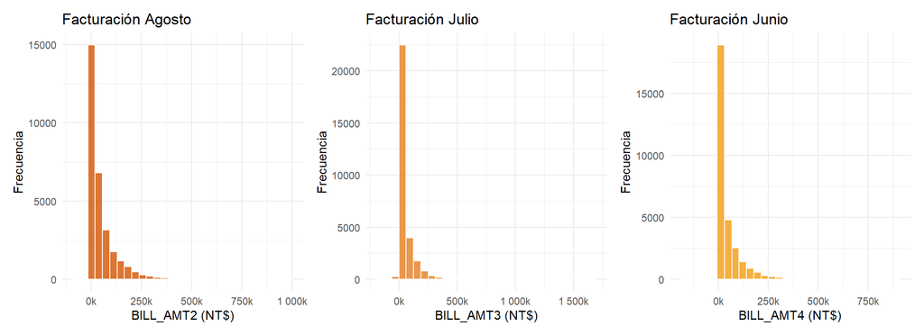

```r
p4 <- ggplot(df, aes(x = BILL_AMT2)) +
  geom_histogram(bins = 30, fill = "#d35400", color = "white", alpha = 0.8) +
  scale_x_continuous(labels = label_number(scale = 1e-3, suffix = "k")) +
  labs(title = "Facturación Agosto", x = "BILL_AMT2 (NT$)", y = "Frecuencia") +
  theme_minimal()

p5 <- ggplot(df, aes(x = BILL_AMT3)) +
  geom_histogram(bins = 30, fill = "#e67e22", color = "white", alpha = 0.8) +
  scale_x_continuous(labels = label_number(scale = 1e-3, suffix = "k")) +
  labs(title = "Facturación Julio", x = "BILL_AMT3 (NT$)", y = "Frecuencia") +
  theme_minimal()

p6 <- ggplot(df, aes(x = BILL_AMT4)) +
  geom_histogram(bins = 30, fill = "#f39c12", color = "white", alpha = 0.8) +
  scale_x_continuous(labels = label_number(scale = 1e-3, suffix = "k")) +
  labs(title = "Facturación Junio", x = "BILL_AMT4 (NT$)", y = "Frecuencia") +
  theme_minimal()

p4 + p5 + p6
```

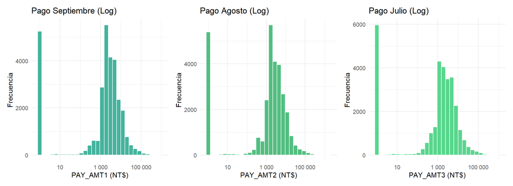

```r
p7 <- ggplot(df, aes(x = PAY_AMT1 + 1)) +
  geom_histogram(bins = 30, fill = "#16a085", color = "white", alpha = 0.8) +
  scale_x_log10(labels = label_number()) +
  labs(title = "Pago Septiembre (Log)", x = "PAY_AMT1 (NT$)", y = "Frecuencia") +
  theme_minimal()

p8 <- ggplot(df, aes(x = PAY_AMT2 + 1)) +
  geom_histogram(bins = 30, fill = "#27ae60", color = "white", alpha = 0.8) +
  scale_x_log10(labels = label_number()) +
  labs(title = "Pago Agosto (Log)", x = "PAY_AMT2 (NT$)", y = "Frecuencia") +
  theme_minimal()

p9 <- ggplot(df, aes(x = PAY_AMT3 + 1)) +
  geom_histogram(bins = 30, fill = "#2ecc71", color = "white", alpha = 0.8) +
  scale_x_log10(labels = label_number()) +
  labs(title = "Pago Julio (Log)", x = "PAY_AMT3 (NT$)", y = "Frecuencia") +
  theme_minimal()

p7 + p8 + p9
```

Dado que los pagos presentan un sesgo extremo a la derecha, se aplica transformación logarítmica ($\log_{10}(x + 1)$) para visualizar mejor la distribución, ya que cuando se hizo sin esto no se visualizaba ningun dato por la magnitud de los mismos, el + 1 se aplica para aquellos valores de 0 ya que el logaritmo de 0 no existe.

## Histogramas Segmentados por Comportamiento de Pago

separamos el conjunto de datos en dos subgrupos independientes: clientes que cumplieron con su pago (`default = 0`) y clientes que entraron en mora (`default = 1`).

```r
# Dividimos el dataframe en dos subconjuntos simples
df_no_mora <- subset(df, default.payment.next.month == 0)
df_mora    <- subset(df, default.payment.next.month == 1)
```

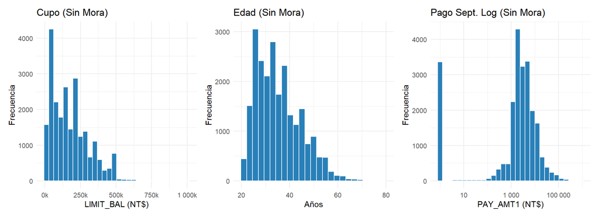

```r
h1_no <- ggplot(df_no_mora, aes(x = LIMIT_BAL)) +
  geom_histogram(bins = 30, fill = "#2980b9", color = "white") +
  scale_x_continuous(labels = label_number(scale = 1e-3, suffix = "k")) +
  labs(title = "Cupo (Sin Mora)", x = "LIMIT_BAL (NT$)", y = "Frecuencia") +
  theme_minimal()

h2_no <- ggplot(df_no_mora, aes(x = AGE)) +
  geom_histogram(bins = 25, fill = "#2980b9", color = "white") +
  labs(title = "Edad (Sin Mora)", x = "Años", y = "Frecuencia") +
  theme_minimal()

h3_no <- ggplot(df_no_mora, aes(x = PAY_AMT1 + 1)) +
  geom_histogram(bins = 30, fill = "#2980b9", color = "white") +
  scale_x_log10(labels = label_number()) +
  labs(title = "Pago Sept. Log (Sin Mora)", x = "PAY_AMT1 (NT$)", y = "Frecuencia") +
  theme_minimal()

# Mostrar bloque de 3
h1_no + h2_no + h3_no
```

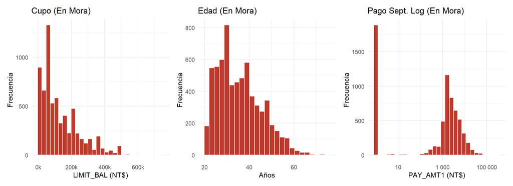

```r
h1_si <- ggplot(df_mora, aes(x = LIMIT_BAL)) +
  geom_histogram(bins = 30, fill = "#c0392b", color = "white") +
  scale_x_continuous(labels = label_number(scale = 1e-3, suffix = "k")) +
  labs(title = "Cupo (En Mora)", x = "LIMIT_BAL (NT$)", y = "Frecuencia") +
  theme_minimal()

h2_si <- ggplot(df_mora, aes(x = AGE)) +
  geom_histogram(bins = 25, fill = "#c0392b", color = "white") +
  labs(title = "Edad (En Mora)", x = "Años", y = "Frecuencia") +
  theme_minimal()

h3_si <- ggplot(df_mora, aes(x = PAY_AMT1 + 1)) +
  geom_histogram(bins = 30, fill = "#c0392b", color = "white") +
  scale_x_log10(labels = label_number()) +
  labs(title = "Pago Sept. Log (En Mora)", x = "PAY_AMT1 (NT$)", y = "Frecuencia") +
  theme_minimal()

# Mostrar bloque de 3
h1_si + h2_si + h3_si
```

# Densidad de kernel

Variables Seleccionadas: - LIMIT_BAL (Monto del cupo crediticio): Variable continua monetaria. El kernel permite observar la forma suave de la masa monetaria asignada e identificar posibles concentraciones o picos en montos estándar - AGE (Edad): Variable cuantitativa con amplio recorrido de 21 a 79 años, la densidad muestra la curvatura demográfica. - BILL_AMT1 a BILL_AMT4 (Facturaciones mensuales): Variables continuas, la curva de densidad permite apreciar el comportamiento alrededor del cero - PAY_AMT1 a PAY_AMT3 (Montos amortizados): Variables monetarias continuas. Al aplicar una escala logarítmica ($\log_{10}(x+1)$), el kernel estima la distribución suave de los hábitos de pago

Para el calculo del h ggplot usa automaticamente la regla de silverman

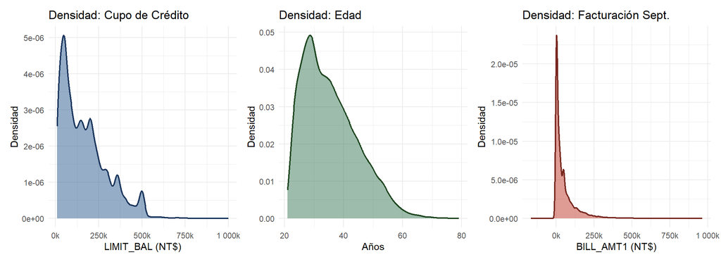

```r
k1 <- ggplot(df, aes(x = LIMIT_BAL)) +
  geom_density(fill = "#2b5c8f", color = "#1a365d", alpha = 0.5, linewidth = 0.8) +
  scale_x_continuous(labels = label_number(scale = 1e-3, suffix = "k")) +
  labs(title = "Densidad: Cupo de Crédito", x = "LIMIT_BAL (NT$)", y = "Densidad") +
  theme_minimal()

k2 <- ggplot(df, aes(x = AGE)) +
  geom_density(fill = "#3b7a57", color = "#1e4620", alpha = 0.5, linewidth = 0.8) +
  labs(title = "Densidad: Edad", x = "Años", y = "Densidad") +
  theme_minimal()

k3 <- ggplot(df, aes(x = BILL_AMT1)) +
  geom_density(fill = "#c0392b", color = "#78281f", alpha = 0.5, linewidth = 0.8) +
  scale_x_continuous(labels = label_number(scale = 1e-3, suffix = "k")) +
  labs(title = "Densidad: Facturación Sept.", x = "BILL_AMT1 (NT$)", y = "Densidad") +
  theme_minimal()

k1 + k2 + k3
```

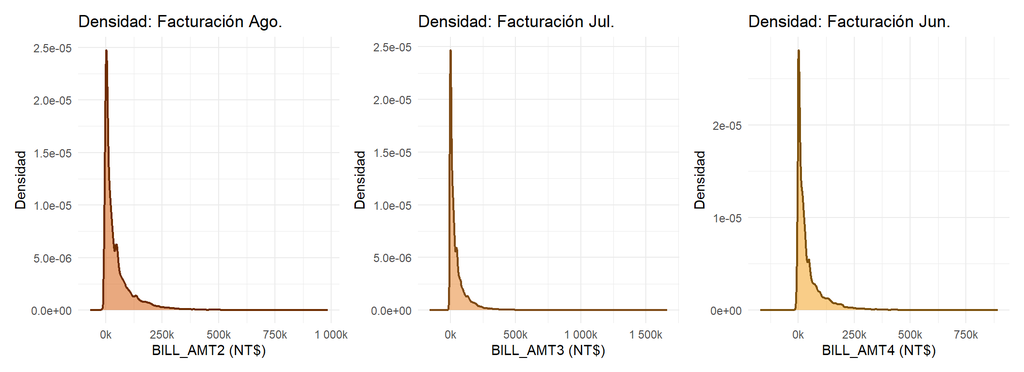

```r
k4 <- ggplot(df, aes(x = BILL_AMT2)) +
  geom_density(fill = "#d35400", color = "#6e2c00", alpha = 0.5, linewidth = 0.8) +
  scale_x_continuous(labels = label_number(scale = 1e-3, suffix = "k")) +
  labs(title = "Densidad: Facturación Ago.", x = "BILL_AMT2 (NT$)", y = "Densidad") +
  theme_minimal()

k5 <- ggplot(df, aes(x = BILL_AMT3)) +
  geom_density(fill = "#e67e22", color = "#7e4a15", alpha = 0.5, linewidth = 0.8) +
  scale_x_continuous(labels = label_number(scale = 1e-3, suffix = "k")) +
  labs(title = "Densidad: Facturación Jul.", x = "BILL_AMT3 (NT$)", y = "Densidad") +
  theme_minimal()

k6 <- ggplot(df, aes(x = BILL_AMT4)) +
  geom_density(fill = "#f39c12", color = "#7d510c", alpha = 0.5, linewidth = 0.8) +
  scale_x_continuous(labels = label_number(scale = 1e-3, suffix = "k")) +
  labs(title = "Densidad: Facturación Jun.", x = "BILL_AMT4 (NT$)", y = "Densidad") +
  theme_minimal()

k4 + k5 + k6
```

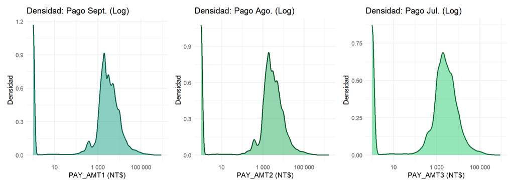

```r
k7 <- ggplot(df, aes(x = PAY_AMT1 + 1)) +
  geom_density(fill = "#16a085", color = "#0e6251", alpha = 0.5, linewidth = 0.8) +
  scale_x_log10(labels = label_number()) +
  labs(title = "Densidad: Pago Sept. (Log)", x = "PAY_AMT1 (NT$)", y = "Densidad") +
  theme_minimal()

k8 <- ggplot(df, aes(x = PAY_AMT2 + 1)) +
  geom_density(fill = "#27ae60", color = "#145a32", alpha = 0.5, linewidth = 0.8) +
  scale_x_log10(labels = label_number()) +
  labs(title = "Densidad: Pago Ago. (Log)", x = "PAY_AMT2 (NT$)", y = "Densidad") +
  theme_minimal()

k9 <- ggplot(df, aes(x = PAY_AMT3 + 1)) +
  geom_density(fill = "#2ecc71", color = "#196f3d", alpha = 0.5, linewidth = 0.8) +
  scale_x_log10(labels = label_number()) +
  labs(title = "Densidad: Pago Jul. (Log)", x = "PAY_AMT3 (NT$)", y = "Densidad") +
  theme_minimal()

k7 + k8 + k9
```